# Project 2

STATS 220 Semester One 2023

Emily Cai

2023-04-23

## Introduction

- I decided to focus on exploring the learning preferences of people learning different languages. I was curious to see how interested people were in learning a new language, what languages people currently know, if people were making a conscious effort to learn new languages, etc.
- One of the guidelines I considered when creating this Google Form was Guideline 1: Communicate your purpose. I considered this while designing my form by adding an introduction explaining the purpose of the data collection, including who it will be shared with.
- The categorical data that was generated using my questions with check boxes (fixed options) means the Google sheet data collected using my form is not strictly tidy data because the data from each respondent are put into one cell in the Google sheet. If the respondent chooses multiple answers, the answers will all be inputted into a singular cell for each entity, separated by commas. This is not tidy data as there are multiple answers per cell.
- Here is the link to my survey

## Analytics

- Here is the link to my published CSV file

My survey got 28 responses. These are the first 10 responses of my survey.

| Timestamp | number_language_spoken | name_languages_spoken | language_interest | selflearn_language | language_wanttolearn | uoa_language_courses | most_important_language |
| --- | --- | --- | --- | --- | --- | --- | --- |
| 25/03/2023 22:00:10 | 4 | English, Chinese | 8 | No | Japanese | NA | Mandarin |
| 25/03/2023 22:00:17 | 2 | English, Chinese | 6 | No | Japanese | NA | Mandarin |
| 25/03/2023 22:14:49 | 3 | English, Chinese | 9 | Yes | Japanese | NA | Chinese |
| 25/03/2023 22:19:41 | 2 | English | 9 | Yes | Korean | NA | Chinese |
| 25/03/2023 22:21:20 | 4 | English, French, Hindi | 8 | No | Chinese | NA | Probably Chinese |
| 25/03/2023 22:30:16 | 4 | English, Chinese | 10 | Yes | Hindi | JAPANESE331 | Mandarin |
| 25/03/2023 22:38:56 | 3 | English, Spanish | 10 | Yes | Japanese | SPANISH104 | Portuguese |
| 25/03/2023 23:02:48 | 1 | English | 8 | Yes | German | NA | Spanish |
| 25/03/2023 23:05:12 | 2 | English, Chinese | 8 | Yes | French | NA | Spanish |
| 25/03/2023 23:35:46 | 1 | English | 8 | Yes | Spanish | NA | Spanish |

### Summary Statistics

- Out of a scale from 1-10, the mean number the 28 respondents rated their interest for learning a new language was 7.5.
- The maximum number of languages spoken by respondents was 5.

### Bar Charts

This is a bar chart showing the languages that respondents of the survey most wanted to learn.

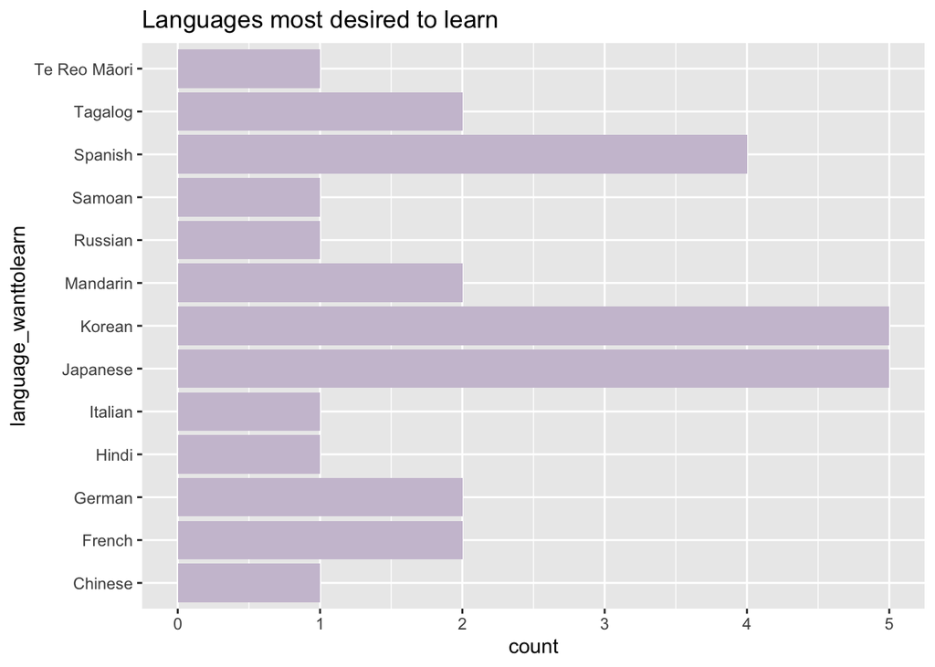

This is a bar chart showing numbers of languages that respondents can already speak at a conversational or higher level.

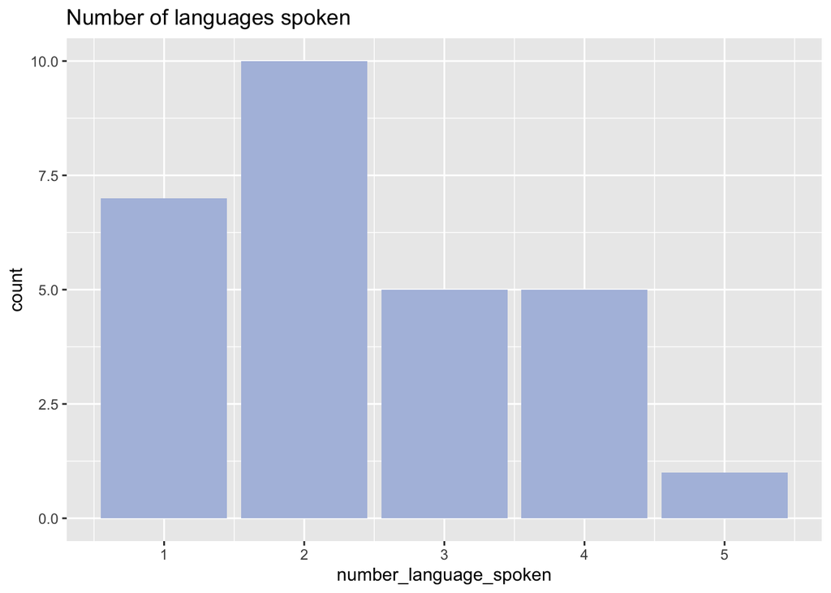

## Learning Reflection

- An important idea I learnt from Module 2: Creating dynamic reporting systems is that we need to take measures in designing surveys for collecting data in a way that gives us the most useful and clean data in the first place possible, so that it will be easier when we wrangle and clean our data later. An example of doing this is to use regex in our forms to restrict the types of answers our respondents give us.
- I demonstrated creativity in this project by:
1. Using regex in my google form questions: I added an extra question in the form asking for the names of any language courses the student has taken at The University of Auckland. I added the regular expression ‘[A-Z]{5,10}[0-9]{3}’ to ensure that respondents entered a word between 5 and 10 characters followed by a number of 3 digits as this is the format that the languages courses at UoA follow.
2. Using skills/knowledge covered in Module 1 not asked for in this project such as: adding a CSS chunk to the index.Rmd file to alter the visual appearance of the file, changing properties such as text/background color and font imported from Google Fonts.
- I am now curious about the different types of databases that data can be stored in. In class we have learnt about relational databases. I would like to learn more about the use of hierarchical/network databases and object-oriented/NoSQL databases and the differences between each one, as well as why we would choose to use one over another in different circumstances.